# Analyzing the Forest

Prelim Analysis

Author

Matt McGehee (Advisor: Dr. Seals)

Published

October 8, 2024

## Introduction

The objective of this analysis is to apply the Random Forest algorithm to better understand patterns in sales data. The dataset contains sales information, including details such as `SalesOrderID`, `CustomerPO`, `TotalPrice`, `UnitPrice`, and `qtyOrdered`. The primary goals of the analysis include identifying important variables, detecting outliers, and predicting purchasing behavior.

Data cleaning was performed to remove outliers and filter out irrelevant products, such as shipping line items. Additionally, proximity analyses were conducted using the Random Forest proximity scores to further understand customer relationships and outlier detection.

## Load necessary libraries

```r
library(randomForest)
library(caret)
library(dplyr)
library(cluster)
library(knitr)
library(kableExtra)
```

## Data Extraction

Read in the data from the corresponding ‘csv’ file that contains the sales data.

```r
sales_data <- read.csv("data_as_csv.csv")
```

## Data Cleaning and Preprocessing

The raw dataset initially contained some irrelevant products, including shipping line items and “credits back” to customers, which were not relevant to our analysis. To ensure accurate analysis, the following filtering steps were applied:

- Excluded products related to shipping and fees, such as “OUTBOUND SHIPPING”, “Shipping Charge”.
- Filtered out negative `UnitPrice`, `TotalPrice`, and `qtyOrdered` values to focus on meaningful transactions.
- Grouped the dataset by `CustomerPO` to aggregate sales at the purchase order level and obtain summary statistics, such as total quantity ordered and total price per order.

This filtering step was critical in ensuring the dataset was clean and focused only on relevant, positive sales transactions.

```r
exclude_products <- c("OUTBOUND SHIPPING", "Outbound Shipping", "Shipping Charge", "SHIPPING CHARGE")

filtered_data <- sales_data %>%
  filter(UnitPrice > 0, TotalPrice > 0, qtyOrdered > 0, !Product %in% exclude_products)
```

### Variable Selection

In this analysis, variables like `TotalPrice`, `qtyOrdered`, and `UnitPrice` were prioritized because they provide direct insights into customer behavior, such as spending patterns and order size.

`Product` and `Substrate` were omitted from the clustering and proximity analysis for the following reasons: - **High Cardinality**: Both fields contain many unique values, which could introduce noise and reduce the effectiveness of clustering. - **Relevance to Customer Segmentation**: The primary goal was to segment customers based on purchasing behavior. Variables like `TotalPrice` and `qtyOrdered` reflect customer activity more effectively than product-level details. - **Avoiding Overfitting**: Including product-specific fields could lead to overfitting, where the model captures unnecessary product-level variations rather than broader purchasing patterns.

By focusing on generalizable metrics, the analysis was able to identify distinct customer segments based on behavior rather than specific products.

## Analysis

```r
cluster_data <- filtered_data %>%
  group_by(CustomerPO) %>%  # You can group by other variables like SalesOrderID if preferred
  summarise(
    TotalPrice = sum(TotalPrice),
    qtyOrdered = sum(qtyOrdered),
    UnitPrice = mean(UnitPrice)
  )

# Step 2: Summary statistics to detect outliers
summary(cluster_data)
```

```
  CustomerPO          TotalPrice          qtyOrdered        UnitPrice
 Length:6076        Min.   :      4.9   Min.   :    1.0   Min.   :  0.8164
 Class :character   1st Qu.:   1965.1   1st Qu.:   33.0   1st Qu.: 47.9381
 Mode  :character   Median :   7887.5   Median :  152.0   Median : 55.0908
                    Mean   :  16812.7   Mean   :  323.4   Mean   : 59.6445
                    3rd Qu.:  26570.5   3rd Qu.:  580.5   3rd Qu.: 68.1659
                    Max.   :2179845.2   Max.   :74719.7   Max.   :339.8400
```

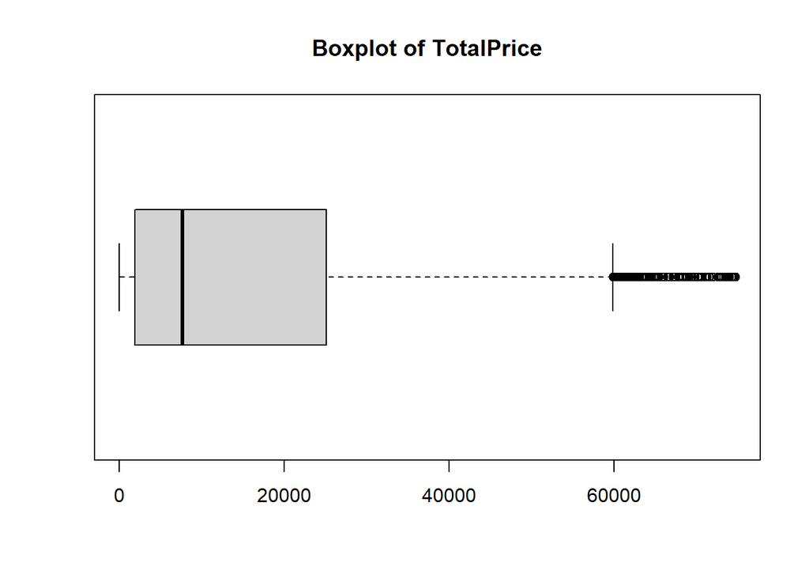

```r
# Step 4: Define threshold to filter out extreme outliers
quantile_threshold <- 0.99  # Remove top 1%
price_threshold <- quantile(cluster_data$TotalPrice, quantile_threshold)
qty_threshold <- quantile(cluster_data$qtyOrdered, quantile_threshold)

# Step 5: Filter out extreme outliers
cluster_data_filtered <- cluster_data %>%
  filter(TotalPrice <= price_threshold, qtyOrdered <= qty_threshold)

boxplot(cluster_data_filtered$TotalPrice, main = "Boxplot of TotalPrice", horizontal = TRUE)
```

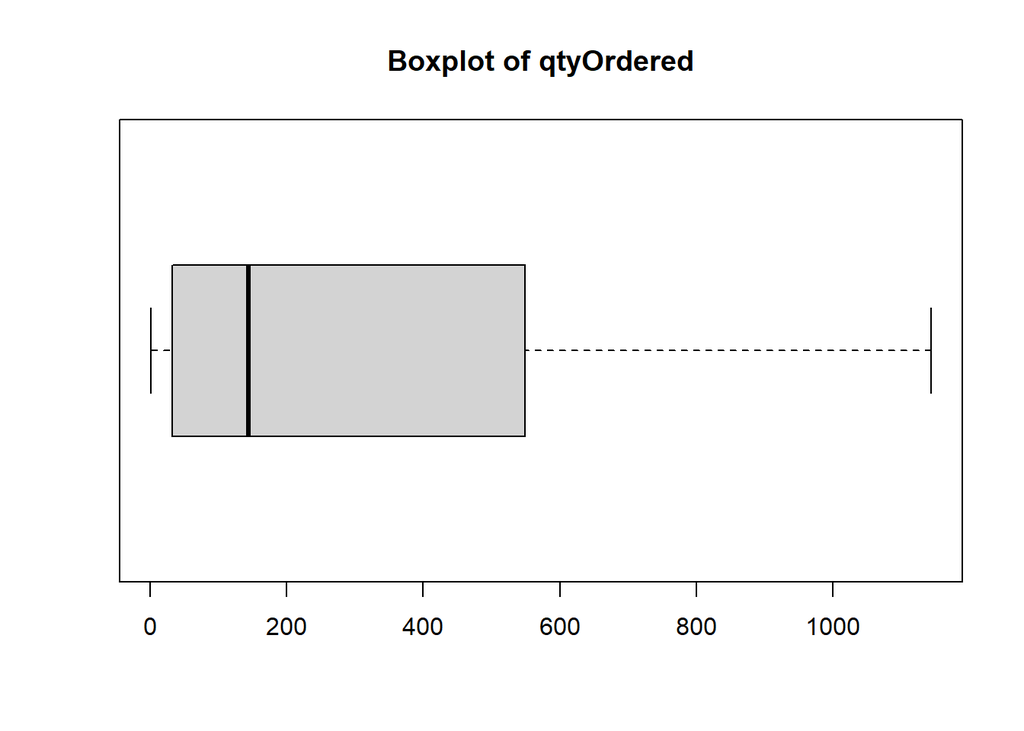

```r
boxplot(cluster_data_filtered$qtyOrdered, main = "Boxplot of qtyOrdered", horizontal = TRUE)
```

```r
# Step 6: Fit Random Forest model (predicting TotalPrice based on qtyOrdered and UnitPrice)
```

### Figure 1: Feature Importance in Random Forest Model

This plot shows the relative importance of `qtyOrdered` and `UnitPrice` in predicting total order value (`TotalPrice`). Features with a higher increase in node purity (on the X-axis) contribute more to reducing the impurity in the model, indicating higher importance. Here, `qtyOrdered` is the most influential predictor of `TotalPrice`.

```r
set.seed(123)
# Create Random Forest model to determine feature importance
rf_model <- randomForest(TotalPrice ~ qtyOrdered + UnitPrice, data = cluster_data_filtered, ntree = 500, proximity = TRUE)
importance(rf_model)
```

```
           IncNodePurity
qtyOrdered  1.570435e+12
UnitPrice   2.226874e+11
```

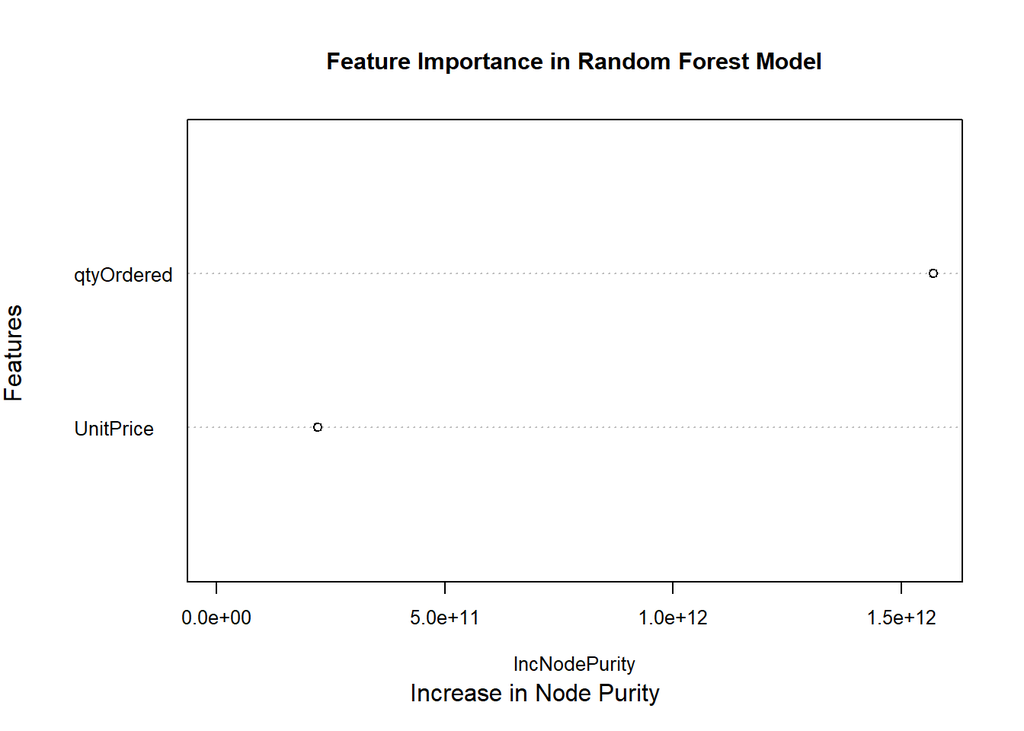

```r
varImpPlot(rf_model, main="Feature Importance in Random Forest Model", cex=0.8)
title(xlab="Increase in Node Purity", ylab="Features")
```

### Figure 2: Proximity Distribution from Random Forest

This plot visualizes the distribution of proximity scores across all customers. Lower proximity scores indicate that customers have similar purchasing behaviors, while higher scores suggest customers with more unique purchasing patterns.

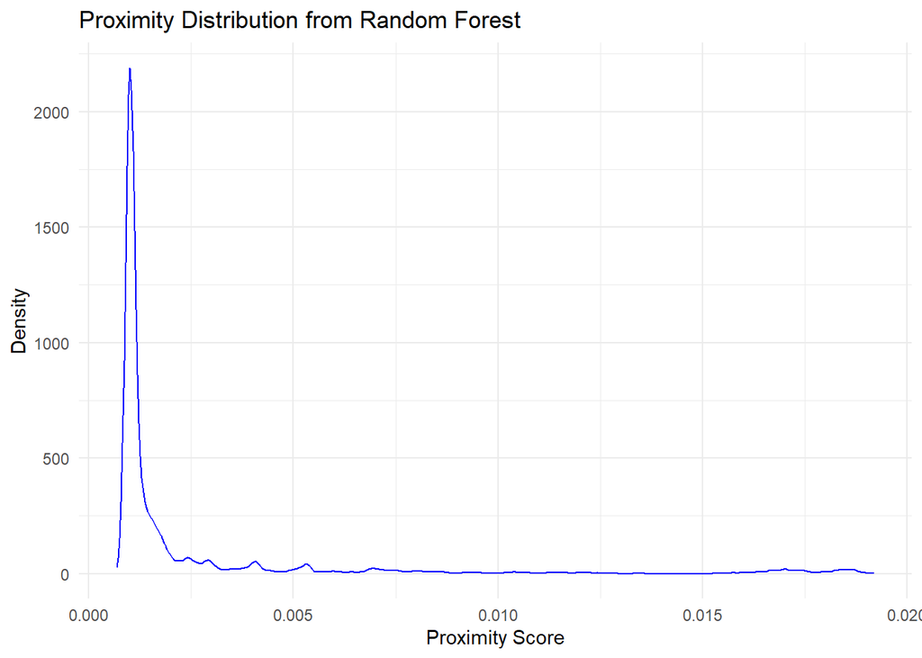

```r
proximity_matrix <- rf_model$proximity

proximity_data <- as.data.frame(proximity_matrix)
proximity_data$CustomerPO <- rownames(proximity_matrix)

# Calculate the average proximity (distance) for each point
proximity_data$Proximity <- apply(proximity_matrix, 1, function(x) mean(x))

# Proximity Distribution Plot
ggplot(proximity_data, aes(x = Proximity)) +
  geom_density(alpha = 0.7, color="blue") +
  labs(title="Proximity Distribution from Random Forest",
       x="Proximity Score", y="Density") +
  theme_minimal()
```

```r
outlier_threshold <- quantile(proximity_data$Proximity, 0.95)  # Top 5% as outliers
proximity_data$Segment <- ifelse(proximity_data$Proximity > outlier_threshold, "Outliers", "Main Group")
```

### Figure 3: Outlier Detection Based on Random Forest Proximity

This plot shows how customers are segmented into the “Main Group” and “Outliers” based on their proximity scores. Customers with lower proximity scores are grouped into the “Main Group,” while customers with proximity scores in the top 5% are flagged as “Outliers,” indicating unique purchasing behavior.

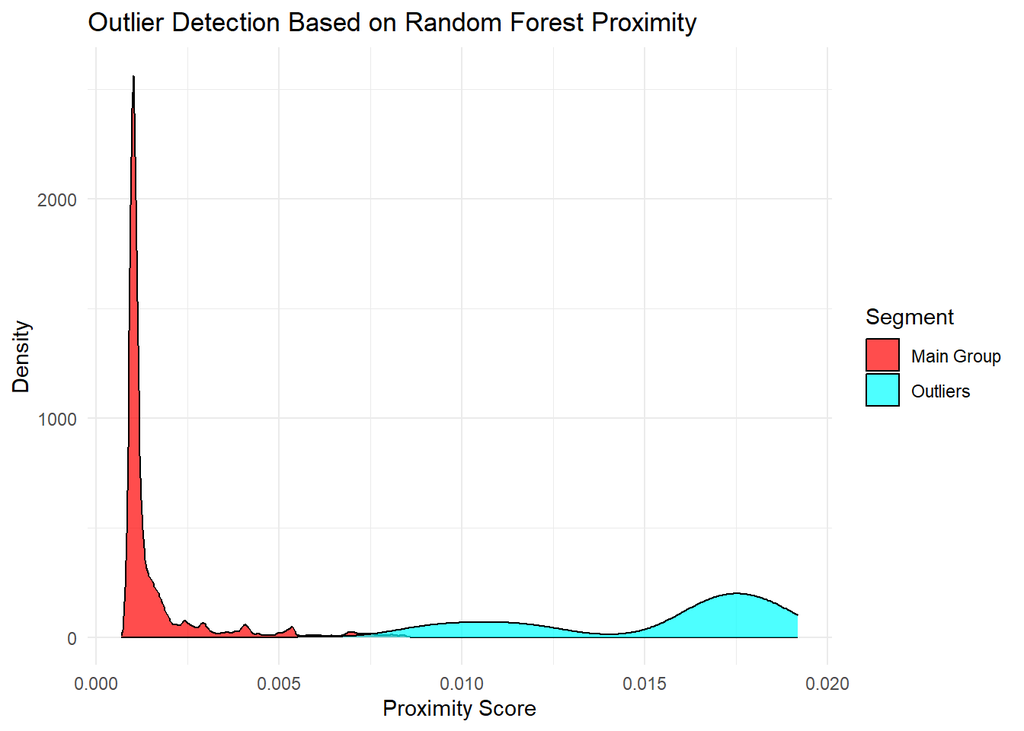

```r
# Outlier Detection Based on Proximity
ggplot(proximity_data, aes(x = Proximity, fill = Segment)) +
  geom_density(alpha = 0.7) +
  labs(title="Outlier Detection Based on Random Forest Proximity",
       x="Proximity Score", y="Density") +
  scale_fill_manual(values=c("Main Group"="red", "Outliers"="cyan")) +
  theme_minimal()
```

```r
# Split Data into Training and Testing Sets
set.seed(123)
trainIndex <- createDataPartition(cluster_data_filtered$TotalPrice, p = 0.8, list = FALSE)
train_data <- cluster_data_filtered[trainIndex, ]
test_data <- cluster_data_filtered[-trainIndex, ]

# Train the Random Forest model on the training data
rf_train <- randomForest(TotalPrice ~ qtyOrdered + UnitPrice, data = train_data, ntree = 500)

# Test the model and predict on the test data
test_predictions <- predict(rf_train, test_data)

# Evaluate the performance
performance <- postResample(test_predictions, test_data$TotalPrice)

performance_metrics <- data.frame(
  Metric = c("RMSE", "R-squared", "MAE"),
  Value = c(performance["RMSE"], performance["Rsquared"], performance["MAE"])
)

kable(performance_metrics, col.names = c("Metric", "Value"), caption = "Performance Metrics of Random Forest Model") %>%
  kable_styling(bootstrap_options = c("striped", "hover", "condensed", "responsive"), full_width = F)
```

Performance Metrics of Random Forest Model

|  | Metric | Value |
| --- | --- | --- |
| RMSE | RMSE | 3563.4301440 |
| Rsquared | R-squared | 0.9564598 |
| MAE | MAE | 1498.1469580 |

## Results

The Random Forest algorithm was used to analyze customer purchasing behavior, focusing on predicting total order value (`TotalPrice`) using features such as `qtyOrdered` and `UnitPrice`.

### Feature Importance

The Random Forest model’s feature importance analysis revealed that `qtyOrdered` was the most influential predictor of total order value, followed by `UnitPrice`. This indicates that the quantity of items ordered has the largest impact on the total sales amount, as expected.

### Proximity Analysis

Using the proximity matrix generated by the Random Forest model, customers were grouped based on their similarity in purchasing behavior. The proximity scores helped identify customers whose purchasing habits were similar, allowing for segmentation. A small number of customers were identified as outliers based on their proximity scores, suggesting that these customers exhibited unusual purchasing patterns.

## Conclusion

This analysis applied the Random Forest algorithm to segment customers based on their purchasing behavior and to assess feature importance. The proximity matrix generated by the Random Forest model helped identify distinct customer behaviors, as well as outliers who exhibited unusual purchasing patterns.

Overall, Random Forest proved to be an effective tool for understanding customer segmentation, purchasing behavior, and outlier detection. Future work could expand on this by incorporating additional variables such as customer demographics or product categories to further refine customer behavior insights.